# Numérilab - Introduction à Google Earth Engine

Esteban Hamel et Arthur de Grandpré

14 janvier 2021

```r
library(knitr)
library(png)
```

# Résumé

Cet atelier Numérliab a pour objectif d’introduire la plateforme Google Earth Engine (EE) et certaines de ses fonctionnalités.

Earth Engine est un logiciel en ligne de la compagnie Google qui met à la disposition de ses utilisateurs une grande variété de couches géographiques (images satellitaires, données climatiques, topographiques, etc.), ainsi que des outils pour les analyser. L’avantage de EE est qu’une grande majorité des calculs sont faits directement par les serveurs de Google sur le cloud, donc beaucoup plus rapidement que sur un ordinateur personnel. Le but de cet atelier n’est pas d’apprendre un nouveau language de programmation, mais plutôt de présenter certains outils et codes reproductibles et adaptables à vos besoins.

# Objectifs

- Importer et visualiser des images satellites propres à une région et un moment donné
- Travailler avec des images satellites pour une région déterminée par un fichier shapefile
- Faire un calcul du NDVI
- Faire une classification d’image satellite
- Exporter les couches produites sous forme de raster

# Étape 1 : Introduction à l’interface EE

### NOTE : AJOUT DE LIENS / MÉTHODES D’ACCÈS A EE? p-e un peu plus d’intro de base

Voici quelques informations pour vous retrouver dans l’interface

[figure not shown]

### NOTE: P-E grandir la figure un peu?

**Panneau de gauche**  
- Bibliothèque où sont enregistrés tous vos codes  
- Bibliothèque de GEE où sont les exemples de codes et la description des outils GEE  
- Bibliothèque de vos propres couches (shapefiles, raster et autres bases de données).

**Panneau du centre**  
- Éditeur de code où vous faites vos calculs

**Panneau de droite**  
- Onglet d’inspection de la couche pour inspecter les métadonnées de votre carte (informations sur les couches et les pixels)  
- Console des sorties où l’information des différentes cartes ou les graphiques s’affichent  
- Gestionnaire de tâche pour les documents importés ou exportés

**Barre de recherche**  
- Pour rechercher un lieu ou des couches de données

**Carte**  
- Carte interactive où sont affichées vos couches calculées par-dessus une carte typique de Google

# Étape 2 : Sélectionner un lieu d’intérêt à l’aide des outils de géométrie

Naviguer sur la carte jusqu’au Parc National de la Mauricie. Il est aussi possible de faire une recherche à l’aide de la barre de recherche, p. ex. “Shawinigan”.

1. À l’aide de l’outil de géométrie, « ajouter un repère » en cliquant sur le pictogramme de repère et déposez-le au milieu du Parc national.
2. Cliquer sur « exit » une fois que le repère est placé
3. Renommer le nouveau repère « pnm » dans le haut de votre script

*Alternative*, utiliser la ligne de code suivante

```javascript
var pnm = /* color: #d63000 */ee.Geometry.Point([-72.97, 46.74])
```

**N’oubliez pas d’enregistrer votre code à l’aide du bouton enregistrer**

[figure not shown]

# Étape 3 : Charger et afficher une carte de l’élévation

Pour importer une couche, vous devrez la charger à partir de la banque de données de Earth Engine. Pour cela, il suffit de rechercher au sein du catalogue EE à l’aide de la barre de recherche et de l’importer. À noter que lorsqu’une couche est importée elle ne s’affichera pas directement. Comme aucunes limites n’ont été spécifiées pour cette couche, elle contient l’information reliée à une énorme superficie et le mieux est de la filtrer pour avoir un affichage autour d’un lieu d’intérêt. Voici un exemple avec des données d’élévation.

- Pour ajouter la couche d’élévation SRTM, rechercher et sélectionner la couche NASA SRTM Digital Elevation 30m
- Vous pouvez consulter l’information disponible pour cette couche dans les différents onglets du panneau qui s’est affiché. Ensuite, cliquez sur importer pour que la couche s’ajoute à votre environnement EE.

[figure not shown]

- Une fois ajoutée, vous pouvez renommer la couche « srtm »

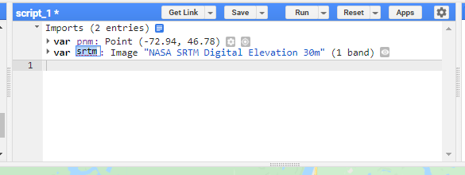

- Pour afficher les propriétés de la couche importée utiliser le code suivant et le résultat s’affichera dans le panneau droit

```javascript
print(srtm);
```

- Pour afficher la couche srtm, il suffit d’utiliser la commande « Map.addLayer » qui permet d’ajouter une couche à la carte. Cependant il faut souvent définir des paramètres de visualisation pour améliorer les paramètres par défaut des couches.

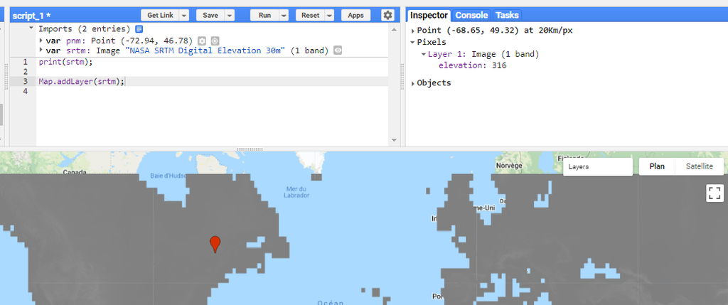

```javascript
Map.addLayer(srtm);
```

- Pour afficher plus en détail le relief, il suffit de mettre des valeurs de relief plus près de celle de notre lieu d’intérêt. Il est aussi possible d’ajouter un nom à la couche que vous faites afficher.

```javascript
Map.addLayer(srtm, {min: 0, max: 400},"Élévation");
```

- Pour faciliter la visualisation de l’élévation, il est possible de donner un gradient de couleur aux valeurs d’élévation.

[figure not shown]

```javascript
Map.addLayer(srtm, {min: 0, max: 400, palette: ['blue', 'yellow', 'red']},"Élévation colorée");
```

- L’information sur l’élévation est utile, mais elle peut être complémentée avec d’autres informations comme le relief au sol et les pentes. Les outils ee.Terrain.hillshade() et ee.Terrain.slope() permettent de calculer rapidement ces attributs.

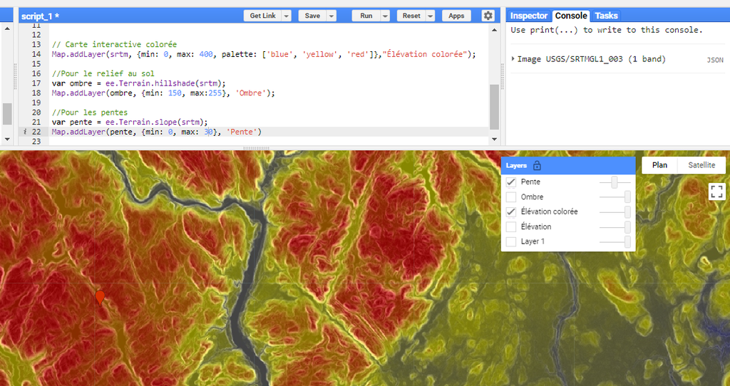

```javascript
var ombre = ee.Terrain.hillshade(srtm);
Map.addLayer(ombre, {min: 150, max:255}, 'Ombre');

var pente = ee.Terrain.slope(srtm);
Map.addLayer(pente, {min: 0, max: 30}, 'Pente')
```

# Étape 4 : Travailler avec des images satellitaires pour une région déterminée

Le catalogue de données de Google Earth Engine permet d’accéder à de nombreuses sources d’images satellitaires. Pour travailler sur d’un lieu d’intérêt, il faudra filtrer les données disponibles pour ce lieu pour une période donnée. Commencez par importer les images du satellite Sentinel 2 (aussi possible pour Landsat).

- Pour ce faire, rechercher « sentinel » dans la barre de recherche et sélectionner «Sentinel-2 MSI : Multispectral Instrument, Level-1C, l’importer puis renommer l’objet « sent2 »

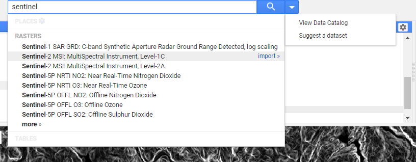

- Utiliser le code ci-dessous pour voir le nombre d’images trouvées autour du lieu d’intérêt qu’est le Parc national de la Mauricie

```javascript
var region_filtre=sent2.filterBounds(pnm)
                                     .filterDate("2020-07-01", "2020-08-30")
                                     .filterMetadata('CLOUDY_PIXEL_PERCENTAGE','less_than',10);

print(region_filtre.size());
```

### NOTE ; la fin de l’étape 4 ne semble pas vraiment fonctionner, la fonction de filtre ne fait pas le lien avec le call d’image et tout. à réviser

# Étape 5 : Sélectionner des images satellitaires selon les contours d’un shapefile

Dans les étapes précédentes, le lieu d’intérêt était le Parc National de la Maurice. Un repère a été placé à un endroit aléatoire dans le Parc. Il est cependant possible de travailler dans Google Earth Engine avec des superficies prédéterminées par exemple dans le cas d’un fichier shapefile. Pour ce faire, il vous faudra importer les fichiers shapefiles de votre ordinateur vers Google Earth Engine.